# Case Study 1: EDA to Create a new Beer for U.S. Craft Enthusiasts

### Budweiser would also like to investigate the difference with respect to IBU and ABV between IPAs (India Pale Ales) and other types of Ale (any beer with “Ale” in its name other than IPA). You decide to use KNN classification to investigate this relationship. Provide statistical evidence one way or the other. You can of course assume your audience is comfortable with percentages … KNN is very easy to understand conceptually.

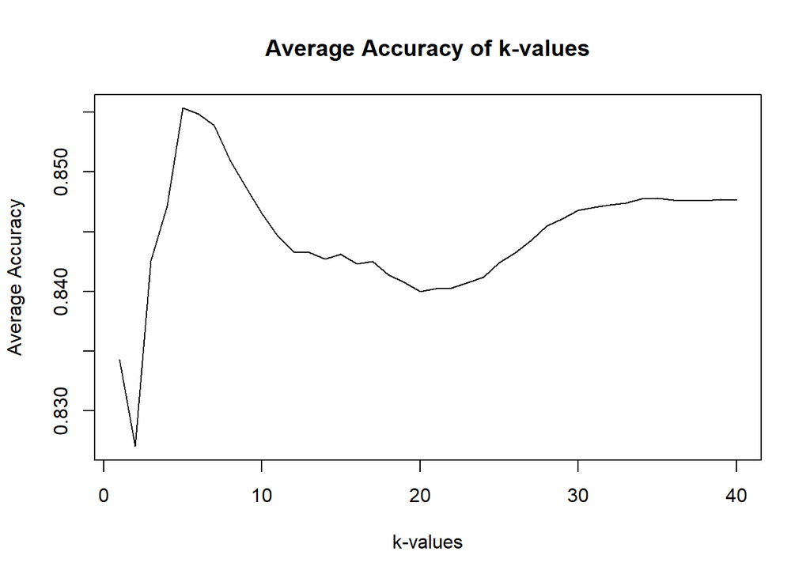

```r
#Filter for all styles that contain 'Ale' or 'India Pale Ale' and create a new data frame.
alesAndIPAs <- beerAndBreweries2 %>% select(Style,ABV,IBU) %>% filter(str_detect(Style, 'Ale') | str_detect(Style, 'IPA'))

# Make all Ales one type, and all IPAs as another type
alesAndIPAs2 = mutate(alesAndIPAs, Type = ifelse(str_detect(Style, 'Ale'), 'Ale', 'IPA'))

# Locate best k value for 70/30 split on knn
splitPerc = .7
# Loop for many k and the average of many training / test partition
iterations = 500
numks = 40
masterAcc = matrix(nrow = iterations, ncol = numks)
for(j in 1:iterations)
{
  accs = data.frame(accuracy = numeric(30), k = numeric(30))
  trainIndices = sample(1:dim(alesAndIPAs2)[1],round(splitPerc * dim(alesAndIPAs2)[1]))
  train = alesAndIPAs2[trainIndices,]
  test = alesAndIPAs2[-trainIndices,]
  for(i in 1:numks)
  {
    classifications = knn(train[,c(2,3)],test[,c(2,3)],train$Type, prob = TRUE, k=i)
    table(classifications,test$Type)
    CM = confusionMatrix(table(classifications,test$Type))
    masterAcc[j,i] = CM$overall[1]
  }
}
# Graph k-values mean accuracies to observe best k-value to use
MeanAcc = colMeans(masterAcc)
plot(seq(1,numks,1),MeanAcc, type = "l",
     main="Average Accuracy of k-values",
     xlab = "k-values",
     ylab = "Average Accuracy")
```

```r
# Grab most accurate k-value (i.e. the one with the highest average accuracy)
strongK = which.max(MeanAcc)

# Use KNN to classify beers that are IPAs vs Ales based on IBU and ABV.
classifications = knn(train[,c(2,3)], test[,c(2,3)], train$Type, k = strongK, prob=T)
# Demonstrate how knn classified the test set against the train set
table(classifications,test$Type)
```

```
##
## classifications Ale IPA
##             Ale 166  21
##             IPA  10  86
```

```r
# Statistics behind classifications table
confusionMatrix(table(classifications,test$Type))
```

```
## Confusion Matrix and Statistics
##
##
## classifications Ale IPA
##             Ale 166  21
##             IPA  10  86
##
##                Accuracy : 0.8905
##                  95% CI : (0.8481, 0.9243)
##     No Information Rate : 0.6219
##     P-Value [Acc > NIR] : < 2e-16
##
##                   Kappa : 0.7623
##
##  Mcnemar's Test P-Value : 0.07249
##
##             Sensitivity : 0.9432
##             Specificity : 0.8037
##          Pos Pred Value : 0.8877
##          Neg Pred Value : 0.8958
##              Prevalence : 0.6219
##          Detection Rate : 0.5866
##    Detection Prevalence : 0.6608
##       Balanced Accuracy : 0.8735
##
##        'Positive' Class : Ale
##
```

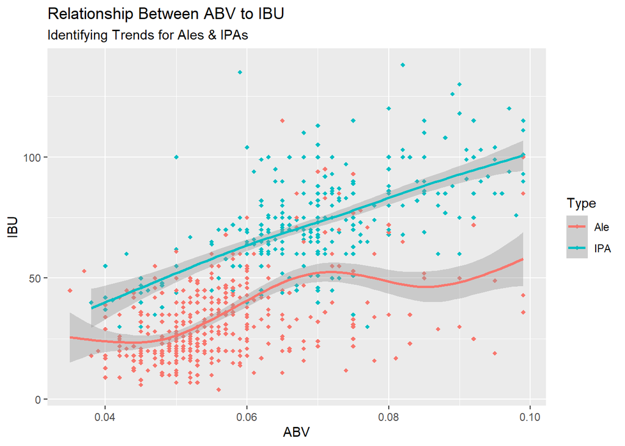

```r
#Show scatterplot based on Type to observe visually the classifications knn may have done
ggplot(alesAndIPAs2, aes(x=ABV, y=IBU, col = Type)) +
  geom_point(shape = "diamond", size = 1.5) +
  geom_smooth(method = 'gam', formula = y ~ s(x, bs = "cs")) +
  labs(title = "Relationship Between ABV to IBU",
       subtitle = "Identifying Trends for Ales & IPAs")
```

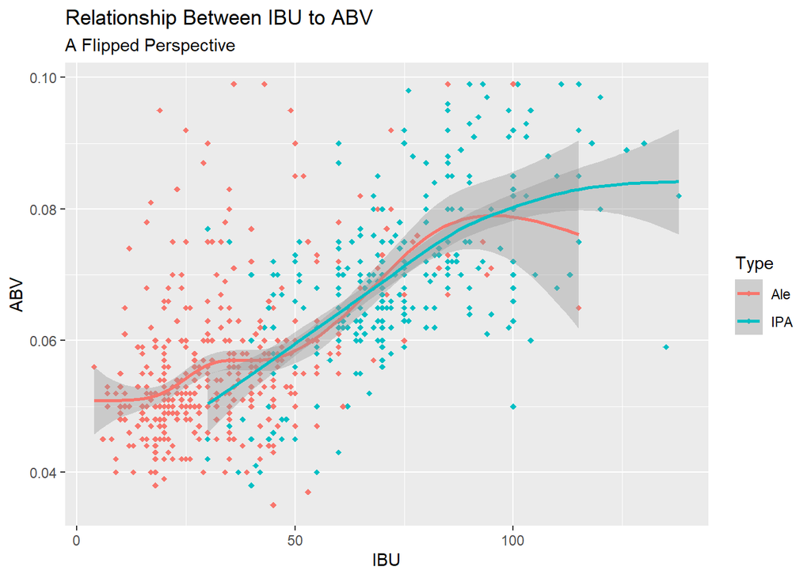

```r
# Flip perspective of continuous variables, notice how trends collide between the two beer types
ggplot(alesAndIPAs2, aes(x=IBU, y=ABV, col = Type)) +
  geom_point(shape = "diamond", size = 1.5) +
  geom_smooth(method = 'gam', formula = y ~ s(x, bs = "cs")) +
  labs(title = "Relationship Between IBU to ABV",
       subtitle = "A Flipped Perspective")
```